# Mapping Auckland Plan submission data

Kate Newton

10 December 2018

This Markdown file imports pre-tidied data from “Analysis of Auckland Plan submissions” to create age, income, and ethnicity visualisations for the RNZ story: ‘White Noise’, published on 21 January, 2019. It only creates the visualisations for the desktop version of the story - the slightly tweaked ggplots used for the mobile versions are not included here. Labels, fonts and some other cosmetic tweaks were made to the saved files in Photoshop.

# Join with local board data

```r
local_board_data <- read_csv("output-data/local-board-data.csv")
local_boards_geo <- left_join(geo, local_board_data, by=c("CB2017_NAM"="Local Board"))

# drop some columns and rename others; calculate rate of submission for each local board

local_boards_geo <- local_boards_geo %>%
  select(-c(CB2017)) %>%
  rename(`Local Board`=CB2017_NAM) %>%
  mutate(per1000.submitted=round(total.submissions/Total.pop*1000, 0))
```

# Join with detailed ethnicity data

```r
ethnic_complete_data <- read_csv("output-data/ethnic-complete-data.csv")

ethnicity_gap_geo <- left_join(geo, ethnic_complete_data, by=c("CB2017_NAM"="Local Board"))

ethnicity_gap_geo <- ethnicity_gap_geo %>%
  arrange(Ethnicity)
```

# Subset the data to create maps showing under/over-representation of each major ethnicity

Rather than facet the data (which would give me maps for ‘Other’ and ‘MELAA’, which aren’t hugely significant in the data), I’ve arranged the dataframe by ethnicity so I can easily subset and visualise a paticular ethnicity (European, Asian, Maori and Pacific).

I’ve used the same colour palette for each, setting the midpoint at 0, the midpoint colour white, and the limits at the biggest +/- pct.gap. This way the gradient remains constant despite the fluctuating percentage gaps in each visualisation.

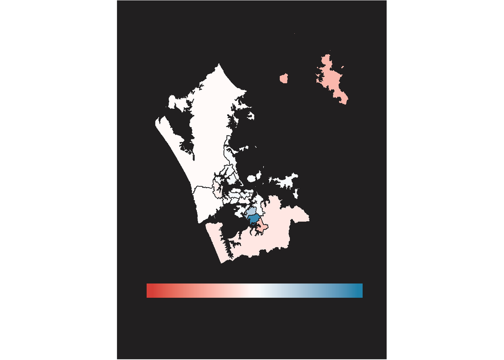

```r
maori_pct <- ethnicity_gap_geo[43:63,]

ggplot(maori_pct) +
  geom_sf(aes(fill=pct.gap), color="#211f20") +
  scale_fill_gradient2(low = "#D63F38",
                       high = "#2081AA", midpoint = 0,
                       guide = "colourbar", name="Percentage gap", limits = c(-31, 31), labels = NULL) +
  theme_void() +
  theme(panel.grid.major = element_line(color="transparent"),
        plot.background = element_rect(fill = "#211f20"),
        plot.margin = unit(c(0.5,1,2,1), "cm"),
        legend.position = "bottom",
        legend.title = element_text(vjust = 0.85)) +
  guides(fill = guide_colourbar(barheight = 1, barwidth = 15, ticks = F, title = NULL))
```

```r
ggsave("viz/maori-final.jpg", width=10.67, height=7.79, dpi=144)
```

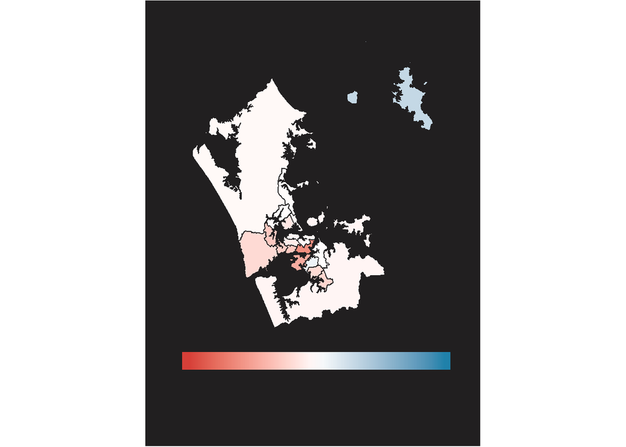

```r
pac_pct <- ethnicity_gap_geo[106:126,]

ggplot(pac_pct) +
  geom_sf(aes(fill=pct.gap), color="#211f20") +
  scale_fill_gradient2(low = "#D63F38",
                       high = "#2081AA", midpoint = 0,
                       guide = "colourbar", name="Percentage gap", limits = c(-31, 31), labels = NULL) +
  theme_void() +
  theme(panel.grid.major = element_line(color="transparent"),
        plot.background = element_rect(fill = "#211f20"),
        plot.margin = unit(c(0.5,1,2,1), "cm"),
        legend.position = "bottom",
        legend.title = element_text(vjust = 0.85)) +
  guides(fill = guide_colourbar(barheight = 1, barwidth = 15, ticks = F, title = NULL))
```

```r
ggsave("viz/pacific-final.jpg", width=10.67, height=7.79, dpi=144)
```

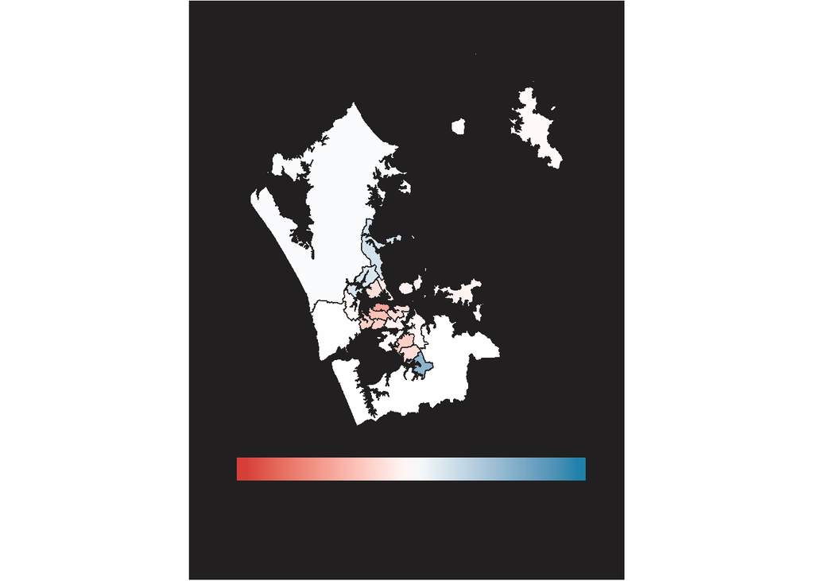

```r
asian_pct <- ethnicity_gap_geo[1:21,]

ggplot(asian_pct) +
  geom_sf(aes(fill=pct.gap), color="#211f20") +
  scale_fill_gradient2(low = "#D63F38",
                       high = "#2081AA", midpoint = 0,
                       guide = "colourbar", name="Percentage gap", limits = c(-31, 31), labels = NULL) +
  theme_void() +
  theme(panel.grid.major = element_line(color="transparent"),
        plot.background = element_rect(fill = "#211f20"),
        plot.margin = unit(c(0.5,1,2,1), "cm"),
        legend.position = "bottom",
        legend.title = element_text(vjust = 0.85)) +
  guides(fill = guide_colourbar(barheight = 1, barwidth = 15, ticks = F, title = NULL))
```

```r
ggsave("viz/asian-final.jpg", width=10.67, height=7.79, dpi=144)
```

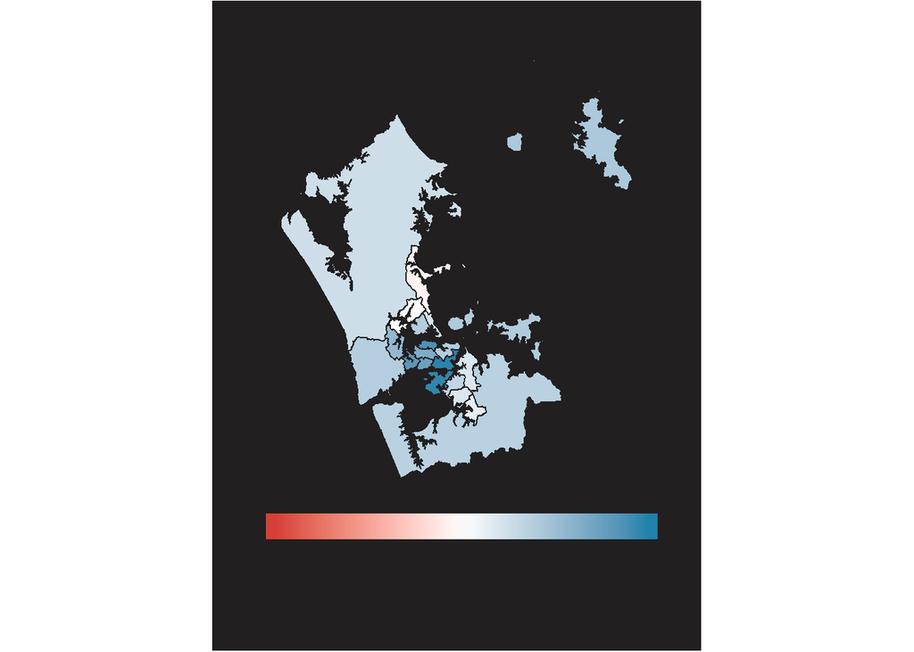

```r
euro_pct <- ethnicity_gap_geo[22:42,]

ggplot(euro_pct) +
  geom_sf(aes(fill=pct.gap), color="#211f20") +
  scale_fill_gradient2(low = "#D63F38",
                       high = "#2081AA", midpoint = 0,
                       guide = "colourbar", name="Percentage gap", limits = c(-31, 31), labels = NULL) +
  theme_void() +
  theme(panel.grid.major = element_line(color="transparent"),
        plot.background = element_rect(fill = "#211f20"),
        plot.margin = unit(c(0.5,1,2,1), "cm"),
        legend.position = "bottom",
        legend.title = element_text(vjust = 0.85)) +
  guides(fill = guide_colourbar(barheight = 1, barwidth = 15, ticks = F, title = NULL))
```

```r
ggsave("viz/pakeha-final.jpg", width=10.67, height=7.79, dpi=144)
```

# Visualising effect of income on submission rates

[figure not shown]

```r
ggplot(local_boards_geo, aes(x=`Median household income`, y=per1000.submitted, size=`total.submissions`, alpha = 0.6)) +
  geom_point(colour="#D63F38", fill="#D63F38") +
  expand_limits(x=30000, y=0) +
  scale_x_continuous(labels=c("$30,000", "$50,000", "$70,000", "$90,000", "$110,000")) +
  ylim(0,40) +
  theme_void() +
  theme(panel.grid.major.y = element_line(color="#EBEAE6", size=0.5),
        plot.background = element_rect(fill = "#221f20"),
        plot.margin = unit(c(5,8,3,4), "cm"),
        panel.grid.minor = element_blank(),
        axis.ticks.y = element_blank(),
        axis.text = element_text(colour="#EBEAE6"),
        axis.text.y = element_text(hjust=-0.1, size = 18),
        axis.text.x = element_text(size = 18),
        axis.title = element_blank(),
        legend.position="none") +
  scale_size(range = c(4,14), breaks = c(0,100,200,300,400,500,600,700,800,900,1000,1100,1200,1300,1400,1500,1600,1700,1800))
```

```r
ggsave("viz/income.jpg", width=10.67, height=7.79, dpi=144)
```

# Visualising age difference between submitters and general population

```r
ages <- read_csv("output-data/ages.csv")
ages_percent <- ages %>%
filter(Age!="No response") %>%
mutate(Percent=(total/sum(total)*100)) %>%
mutate(Percent=round(Percent, digits=2))

# Bring in Auckland population data (using latest June 2018 estimates rather than Census data, seeing as it doesn't need to be broken down by local board)

age_pop <- read_csv("raw-data/age-estimates-2018.csv", skip=5) %>%
select(Age=`Total people, age`, Total=`1695900`)
```

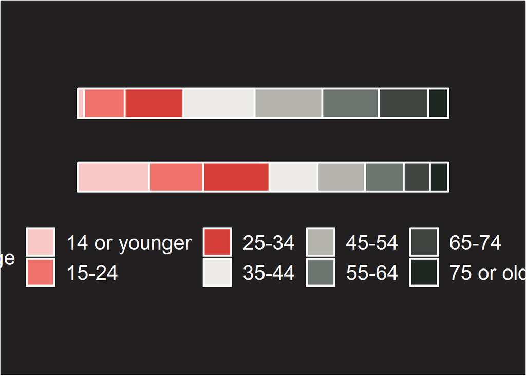

```r
age_pop <- age_pop[-17,]

# The estimates data is in five-year age bands so I need to rename and add rows so it matches the format of the submissions data

age_pop <- age_pop %>%
  mutate(Age = case_when(Age=="0-14 years"~"14 or younger", Age=="15-19 years"~"15-24", Age=="20-24 years"~"15-24", Age=="25-29 years"~"25-34", Age=="30-34 years"~"25-34", Age=="35-39 years"~"35-44", Age=="40-44 years"~"35-44", Age=="45-49 years"~"45-54", Age=="50-54 years"~"45-54", Age=="55-59 years"~"55-64", Age=="60-64 years"~"55-64", Age=="65-69 years"~"65-74", Age=="70-74 years"~"65-74", Age=="75-79 years"~"75 or older", Age=="80-84 years"~"75 or older", Age=="85 years and over"~"75 or older")) %>%
  group_by(Age) %>%
  summarise(Total=sum(Total)) %>%
  mutate(Percent=Total/sum(Total)*100) %>% # add percent column
  mutate(Percent=round(Percent, digits=2))

# Create false y-values so I can force the viz to graph two bars

age_pop$x <- c("Population", "Population", "Population", "Population", "Population", "Population", "Population", "Population")
ages_percent$x <- c("Submissions", "Submissions", "Submissions", "Submissions", "Submissions", "Submissions", "Submissions", "Submissions")

ages_final <- full_join(age_pop, ages_percent) %>%
select(-c(total, Total))
ggplot(ages_final, aes(y=Percent, x=x, fill=Age)) +
geom_bar(stat="identity", position = position_stack(reverse=T), width=0.4, colour="white", size=1) +
scale_fill_manual(values = c("#F9C7C4", "#ef726c", "#D63F38", "#EBEAE6", "#B3B3AC", "#6D7570", "#404441", "#1E2722")) +
coord_flip() +
theme_void() +
theme(legend.position="bottom") +
theme(plot.background = element_rect(fill = "#221f20"),
plot.margin = unit(c(2,2,3,2), "cm"),
legend.text = (element_text(colour = "white", size=20)),
        legend.title = (element_text(colour = "white", size=20)),
legend.key.size = unit(2,"line"))
```

```r
ggsave("viz/age-proportions.jpg", width=10.67, height=7.79, dpi=144)
```